# The Data Analyst – Interview Prep & Skills

Stats’ Thought

Stats’ Life

Data Analyst;  
Interview Preperation;  
Skills;

A Talk from Steve Olson - rewritten by Hai Nguyen  
February 23, 2023

## Thoughts

As a biostatistician role, we also play Data Analysts. With comprehensive and deep knowledge of statistics, we apply available methods and choose the proper method or, if necessary, modify/create a new approach to drive the data into a story that fits.

In general, Steve Olson’s Talk (CCASA Presentation) could tell us about essential requirements to prepare skills and interview for the data analyst.

## Outline

1- Goal of the Data Analyst

2- Hard Skills

- Understanding the Data
- Approach to Analytics
- Creating Valuable Analytic Output
- Test and Learn Principles
- Skills & Tools

3- Soft Skills

- Valuable Analyst Attributes
- Questions to Ask

## Goal of the Data Analyst

The Goal of the Analyst is to generate insights from available data *in service of improving the company or brand Key Performance Indicators (KPIs), goals, metrics*

- Understanding a brand or company’s KPIs and/or goals is foundational as all analytics are conducted in service of KPIs and identifying opportunities to improve the metrics
  - Commerce: Monthly sales, revenue, margin or profit, steal share from specific competitors
  - Marketing: Engagement (CRM) such as email open rates or click through rates, revenue, new names generated
- Examples of questions to be answered through analytics:
  - How are the KPIs trending?
  - Where can we increase sales?
  - Where is engagement strong or lacking?

## How to understand the Data

**All analytics start with a full understanding of the underlying data**

- How to “break down” a dataset:

  1- Know the **exhaustive set of variables and data** with which you are working
  - Data dictionary is sometimes a good starting point – often will just be high level description and format
  - How are different data sets linked? What are the primary keys? (individual id, phone number, store id)

  2- **Calculate basic metrics** to fully understand the data – up to 90% of analytic work – Discovery or EDA
  - Calculate means and medians for each variable
  - Create distribution metrics of each variable: standard deviations, interquartile ranges etc
  - Data ranges
  - Survey data – know the possible answers to each question, the scale
  - Uncover questionable data: missing data, miscoded or incorrect data, outliers
  - Create cross tabs

  3- **Visualize** the distribution of data in the variables
  - Create graphs of distribution frequencies, histograms

## Approach to Analytics

**A single number or metric or datapoint is not an insight**

Metrics require CONTEXT to know it it is “good or bad”

**Analytic approaches to create context:**

1- Benchmarking against past similar timeframes or events

- Compare to last year (YoY), Past promotion comparison, Previous month average

2- Trending over time – is the metric increasing or decreasing?

- line graphs of : past 12 months, year over year
- cohort analysis – Q1 engaged, did they engage in Q2, Q3 etc  
  3- Segmenting the data: how does the metric look for different segments?
- Age groups
- Purchase segments
- High, medium, low engagement tiers

4- Industry benchmarks or comparisons

5- Create maps to determine if there are geographical differences

6- Cumulative response distributions - linear growth or plateau

7- Test results – how did group A perform vs group B?

## Creating Valuable Analytic Output

- Think about the numbers in terms of **telling a story**
  - “The metric appears to be trending in this direction, this might be why, and here is what I think we should do”
- **Make recommendations** – what recommendations do you have because of the story in the data and how might we alter the KPIs ore metrics favorably?
  - Because the metrics are doing this, we should consider doing this
- **Generate hypotheses** – if information is lacking to make a firm recommendation – why might things be trending the way they are – be provocative
  - The metrics may be trending this way because
  - Is there other data that could help explain what you are seeing?
- **Propose testing** – where appropriate to evaluate hypotheses – can a test be set up to confirm or disprove the hypothesis?

## Test and Learn Principles

- Identity A) the metric to change and B) the feature(s) which, if changed, may improve the metric
  - Increase open rates: modify subject lines/preview text
  - Increase online conversion/purchase: add purchase message pop ups or abandon cart messaging
  - Increase sales: increase discount amounts
- Generate a hypothesis – if we change this, this will happen
- Understand the engagement or purchase funnel
  - Is there enough sample to get a read on results?
- Statistical testing
  - Understand statistical vs. practical significant – effect size vs. P values
  - Is the result sizeable enough to warrrant making the change?
  - Random sampling is vital

## Skills & Tools

**Speak the “language” of the different tools you might use** – may not need to be an expert

- Know the basic functions within SQL ana what they do
  - select, from, where
  - different joins and what they do – frequent interview question
- Familiarize yourself with different analytic tools
  - Visualization tools: Excel, Tableau, PowerBI
  - Web analysis: Adobe analytics, Google analytics
  - Statistical languages: R, Python
- Prepare an example for when you learned something similar quickly to be successful

## Soft skills

- Attributes of the Valuable Data Analyst
  - Curiosity - about the business and the metrics
    - You are hungry to understand what is the data telling you
    - You have an appetite for knowing what you can learn from the data
  - Creativity – with data and output
    - Excited to explore different ways to visualize data
    - Ability to explain the findings – you may need to present the data to non-data experts
  - Attention to detail
    - Data errors are easy to make – always double check the work and get others’ feedback
    - Code running without error is not enough – validate the output
  - Ability to have **“Big Picture” view**
    - Step back and ask yourself if the numbers you are presenting make sense
    - Gui check – refer to other work, as others for input

## Questions to ask during the interview

- What kind of data will I be working with?
  - CRM engagement, sales data, media spend, what level (household, individual, store)
- How is the data structured?
  - Relational tables?
  - What are the different datasets?
  - How are different tables linked? (primary keys)
- What are the Key Performance Indicators we are trying to improve?
- Will I be presenting the data and results and who is the audience?
  - Will I be working with others to tell the story?
- What analytic tools are used most often in daily work?

## Sum up

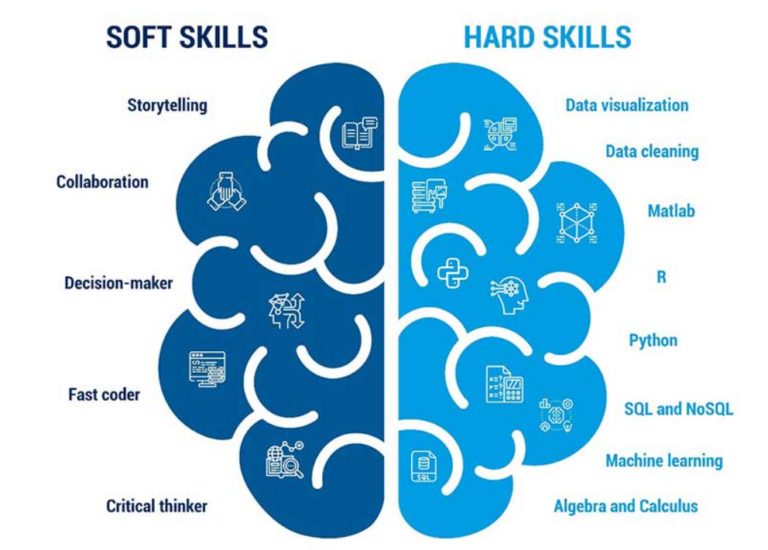

Source: [dasca](https://www.dasca.org/world-of-big-data/article/why-a-data-analyst-requires-a-data-analytics-certification)